# Ford GoBike System Dateset

```python
# check if data have any duplicated value
df.duplicated().sum()
```

```
0
```

```python
# Renaming dataframe columns.
df.rename(columns={"tripduration": "trip_duration",
                   "starttime": "start_time",
                  "stoptime": "stop_time",
                   "start station id":"start_station_id",
                  "start station name": "start_station_name",
                  "start station latitude": "start_station_latitude",
                  "start station longitude": "start_station_longitude",
                  "end station id": "end_station_id",
                  "end station name": "end_station_name",
                  "end station latitude": "end_station_latitude",
                  "end station longitude": "end_station_longitude",
                  "bikeid": "bike_id",
                  "birth year": "birth_year",
                  "usertype": "user_type"},inplace=True)
```

```python
# change the data type for start and end time to be datetime64[ns]
# change the data type of gender to catgorey
df.start_time = pd.to_datetime(df.start_time)
df.stop_time = pd.to_datetime(df.stop_time)
df.gender = df.gender.astype('category')
```

```python
# display the value counts of gender
df.gender.value_counts()
```

```
1    537589
2    151806
0     29599
Name: gender, dtype: int64
```

```python
#replacing gender values
df['gender'].replace([0,1,2],['other','Male','Female'],inplace=True)
```

```python
# convert duration to minutes instead of seconds for easy investigations.
df['trip_duration'] = df['trip_duration']/60
```

```python
# create a column for the age of user
df['User_age']= 2020 - df.birth_year
```

```python
# descriptive statistics for User age
df.User_age.describe()
```

```
count    718994.000000
mean         42.234055
std          12.016931
min          18.000000
25%          32.000000
50%          40.000000
75%          51.000000
max         135.000000
Name: User_age, dtype: float64
```

```python
# change the data type of user age
df.User_age = df.User_age.astype('int64')
```

it's not possible for 135 years old to ride bike so I'm gonna limit the bucket of ages to 80.

```python
# remove any user age over 80 years
df= df[df['User_age'] <= 80]
```

```python
# create new coulmns for start and stop time in hours
df['start_time_hour']= df['start_time'].dt.hour
df['stop_time_hour']= df['stop_time'].dt.hour
```

```python
df.shape
```

```
(717929, 18)
```

```python
df.dtypes
```

```
trip_duration                     float64
start_time                 datetime64[ns]
stop_time                  datetime64[ns]
start_station_id                    int64
start_station_name                 object
start_station_latitude            float64
start_station_longitude           float64
end_station_id                      int64
end_station_name                   object
end_station_latitude              float64
end_station_longitude             float64
bike_id                             int64
user_type                          object
birth_year                          int64
gender                             object
User_age                            int64
start_time_hour                     int64
stop_time_hour                      int64
dtype: object
```

```python
df.info()
```

```
<class 'pandas.core.frame.DataFrame'>
Int64Index: 717929 entries, 0 to 718993
Data columns (total 18 columns):
 #   Column                   Non-Null Count   Dtype
---  ------                   --------------   -----
 0   trip_duration            717929 non-null  float64
 1   start_time               717929 non-null  datetime64[ns]
 2   stop_time                717929 non-null  datetime64[ns]
 3   start_station_id         717929 non-null  int64
 4   start_station_name       717929 non-null  object
 5   start_station_latitude   717929 non-null  float64
 6   start_station_longitude  717929 non-null  float64
 7   end_station_id           717929 non-null  int64
 8   end_station_name         717929 non-null  object
 9   end_station_latitude     717929 non-null  float64
 10  end_station_longitude    717929 non-null  float64
 11  bike_id                  717929 non-null  int64
 12  user_type                717929 non-null  object
 13  birth_year               717929 non-null  int64
 14  gender                   717929 non-null  object
 15  User_age                 717929 non-null  int64
 16  start_time_hour          717929 non-null  int64
 17  stop_time_hour           717929 non-null  int64
dtypes: datetime64[ns](2), float64(5), int64(7), object(4)
memory usage: 104.1+ MB
```

```python
df.head()
```

|  | trip_duration | start_time | stop_time | start_station_id | start_station_name | start_station_latitude | start_station_longitude | end_station_id | end_station_name | end_station_latitude | end_station_longitude | bike_id | user_type | birth_year | gender | User_age | start_time_hour | stop_time_hour |
| --- | --- | --- | --- | --- | --- | --- | --- | --- | --- | --- | --- | --- | --- | --- | --- | --- | --- | --- |
| 0 | 16.166667 | 2018-01-01 13:50:57.434 | 2018-01-01 14:07:08.186 | 72 | W 52 St & 11 Ave | 40.767272 | -73.993929 | 505 | 6 Ave & W 33 St | 40.749013 | -73.988484 | 31956 | Subscriber | 1992 | Male | 28 | 13 | 14 |
| 1 | 12.050000 | 2018-01-01 15:33:30.182 | 2018-01-01 15:45:33.341 | 72 | W 52 St & 11 Ave | 40.767272 | -73.993929 | 3255 | 8 Ave & W 31 St | 40.750585 | -73.994685 | 32536 | Subscriber | 1969 | Male | 51 | 15 | 15 |
| 2 | 8.266667 | 2018-01-01 15:39:18.337 | 2018-01-01 15:47:35.172 | 72 | W 52 St & 11 Ave | 40.767272 | -73.993929 | 525 | W 34 St & 11 Ave | 40.755942 | -74.002116 | 16069 | Subscriber | 1956 | Male | 64 | 15 | 15 |
| 3 | 5.100000 | 2018-01-01 15:40:13.372 | 2018-01-01 15:45:20.191 | 72 | W 52 St & 11 Ave | 40.767272 | -73.993929 | 447 | 8 Ave & W 52 St | 40.763707 | -73.985162 | 31781 | Subscriber | 1974 | Male | 46 | 15 | 15 |
| 4 | 5.100000 | 2018-01-01 18:14:51.568 | 2018-01-01 18:19:57.642 | 72 | W 52 St & 11 Ave | 40.767272 | -73.993929 | 3356 | Amsterdam Ave & W 66 St | 40.774667 | -73.984706 | 30319 | Subscriber | 1992 | Male | 28 | 18 | 18 |

### What is/are the main feature(s) of interest in your dataset?

I'm interested in figuring out how trip duration is dependent on other features such as: age, start_time_hour, stop_time_hour, user type, and gender from the dataset. Also I want to see the relationship between age and start and stop time.

### What features in the dataset do you think will help support your investigation into your feature(s) of interest?

I think the most interesting features on the dataset is trip duration and Its association with the following variables : gender, Age , starttime, stoptime.

## Univariate Exploration

Let's start to analysis and visualizing the dataset

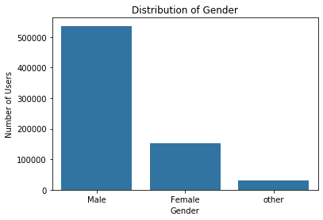

```python
# create a bar chart to find the number of user by their gender
base_color = sns.color_palette()[0]
gender_order = df['gender'].value_counts().index
sns.countplot(data = df, x = 'gender', color = base_color,order =gender_order)
plt.title('Distribution of Gender')
plt.xlabel('Gender')
plt.ylabel('Number of Users');
```

The bar chart shows that the male user has the most number of users.

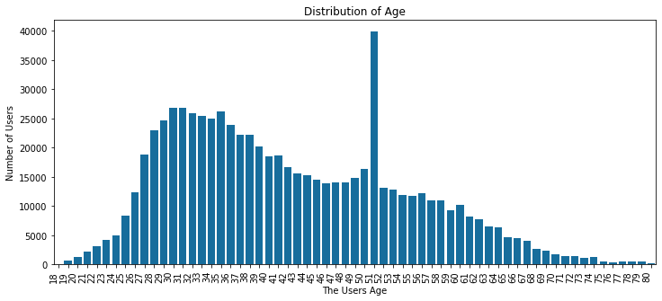

```python
# create a bar chart to find the number of user by their age
base_color = sns.color_palette('colorblind')[0]
plt.figure(figsize=(12,5))
chart = sns.countplot(data=df, x='User_age',color=base_color);
plt.title('Distribution of Age')
plt.xlabel('The Users Age');
plt.ylabel('Number of Users');
chart.set_xticklabels(chart.get_xticklabels(), rotation=90, horizontalalignment='right');
```

The bar chart shows that 51 years old is the age group most frequently reported in the data.

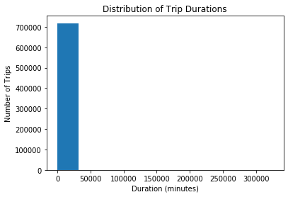

```python
# draw a histogram for Distribution of Trip Durations
plt.hist(data = df, x = 'trip_duration');
plt.title('Distribution of Trip Durations')
plt.xlabel('Duration (minutes)')
plt.ylabel('Number of Trips');
```

the histogram doesn't make any sense so I'm gonna go deeper by converting the scales and transformations.

```python
# descriptive statistics for trip_duration
df.trip_duration.describe()
```

```
count    717929.000000
mean         13.781421
std         547.012611
min           1.016667
25%           5.316667
50%           8.500000
75%          14.033333
max      325167.483333
Name: trip_duration, dtype: float64
```

```python
#limiting the minutes of trip_duration to 150 or less
df = df[df['trip_duration'] <= 150]
df.info()
```

```
<class 'pandas.core.frame.DataFrame'>
Int64Index: 717116 entries, 0 to 718993
Data columns (total 18 columns):
 #   Column                   Non-Null Count   Dtype
---  ------                   --------------   -----
 0   trip_duration            717116 non-null  float64
 1   start_time               717116 non-null  datetime64[ns]
 2   stop_time                717116 non-null  datetime64[ns]
 3   start_station_id         717116 non-null  int64
 4   start_station_name       717116 non-null  object
 5   start_station_latitude   717116 non-null  float64
 6   start_station_longitude  717116 non-null  float64
 7   end_station_id           717116 non-null  int64
 8   end_station_name         717116 non-null  object
 9   end_station_latitude     717116 non-null  float64
 10  end_station_longitude    717116 non-null  float64
 11  bike_id                  717116 non-null  int64
 12  user_type                717116 non-null  object
 13  birth_year               717116 non-null  int64
 14  gender                   717116 non-null  object
 15  User_age                 717116 non-null  int64
 16  start_time_hour          717116 non-null  int64
 17  stop_time_hour           717116 non-null  int64
dtypes: datetime64[ns](2), float64(5), int64(7), object(4)
memory usage: 104.0+ MB
```

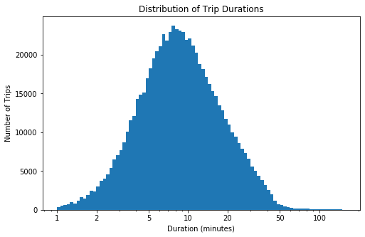

```python
# draw a histogram for Distribution of Trip Durations
bins = 10 ** np.arange(0, np.log10(df['trip_duration'].max())+0.025, 0.025)
plt.figure(figsize=[8, 5]);
plt.hist(data = df, x = 'trip_duration', bins = bins);
plt.xscale('log');
plt.xticks([1, 2, 5, 10, 20, 50, 100], [1, 2, 5, 10, 20, 50, 100]);
plt.title('Distribution of Trip Durations')
plt.ylabel('Number of Trips')
plt.xlabel('Duration (minutes)');
```

The histogram has a normal distrabution and shows that the peak trip duration was on 8 to 10 minutes

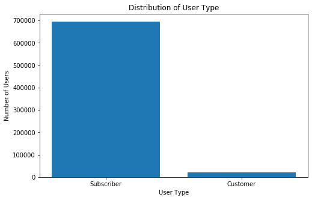

```python
# plotting the count of types of users
plt.figure(figsize=[8,5])
plt.bar(x = df.user_type.value_counts().keys(), height = df.user_type.value_counts() )
plt.title('Distribution of User Type')
plt.xlabel('User Type')
plt.ylabel('Number of Users')
plt.show()
```

As we can see the most users have been subscribed to the bike.

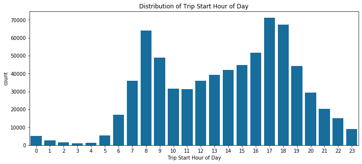

```python
# plot the Distribution of Trip Start Hour of Day
plt.figure(figsize=[12, 5]);
base_color = sns.color_palette('colorblind')[0]

sns.countplot(df['start_time_hour'], color = base_color)
plt.xlabel('Trip Start Hour of Day');
plt.title('Distribution of Trip Start Hour of Day');
```

Obviously most of people use the bike from 17:00 to 18:00

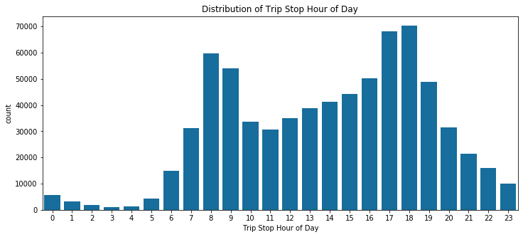

```python
# plot the Distribution of Trip Stop Hour of Day
plt.figure(figsize=[12, 5]);
base_color = sns.color_palette('colorblind')[0]

sns.countplot(df['stop_time_hour'], color = base_color)
plt.xlabel('Trip Stop Hour of Day');
plt.title('Distribution of Trip Stop Hour of Day');
```

Obviously most of people stop use the bike from 17:00 to 18:00 also

### Discuss the distribution(s) of your variable(s) of interest. Were there any unusual points? Did you need to perform any transformations?

yes, I found a long tail in ride bike duration so I used a log transformation to investigate data deeper Interestingly, the trip duration takes a large amount of values and is concentrated at 8 to 10 minutes.

## Bivariate Exploration

I'm interested on trip duration with other variables like : Age and Gender and start station, end station, so I'm gonna find their relationship.

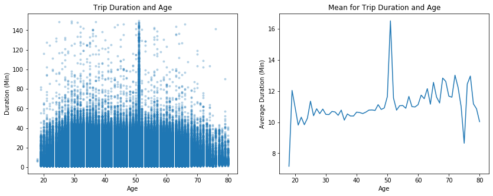

```python
plt.figure(figsize=[14,5]);
#plot scatter without the mean
plt.subplot(1, 2, 1)
plt.scatter(data = df,x ='User_age', y ='trip_duration', alpha = 0.25, marker = '.' )
plt.title('Trip Duration and Age')
plt.xlabel('Age')
plt.ylabel('Duration (Min)')
# lineplot with the mean of trip_duration
plt.subplot(1, 2, 2)
mean_trip_duration= df.groupby('User_age')['trip_duration'].mean().reset_index()
plt.errorbar(data = mean_trip_duration, x = 'User_age', y = 'trip_duration');
plt.title('Mean for Trip Duration and Age')
plt.xlabel('Age')
plt.ylabel('Average Duration (Min)');
```

As we can see there is no clear relationship between the two variables even when I used the mean for trip_duration But for the people on age 51 there is a kind of relationship.

I'll now move on to the other variables in the dataset to look into the duration dependence on Gender

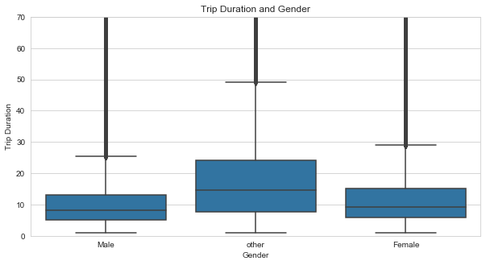

```python
# draw boxplot for Trip Duration and Gender
plt.figure(figsize = [10, 5])
sns.set_style("whitegrid")
base_color = sns.color_palette()[0]
sns.boxplot(data = df, x = 'gender', y = 'trip_duration', color = base_color)
plt.ylim([0, 70])
plt.title('Trip Duration and Gender')
plt.xlabel('Gender')
plt.ylabel('Trip Duration')
plt.show()
```

Interestingly, we can see that Other has highest median of trip duration and female has higher median then Male .Although the max for other and female higher than the male however number of male riders are very high then other and female on the dataset.

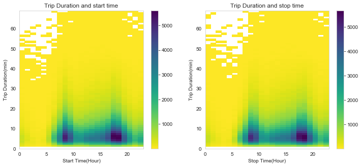

```python
# draw a heatmap to see the relation between trip duration and (start,stop)
plt.figure(figsize = [12, 5])
# draw the heatmap between trip duration and start time
plt.subplot(1, 2, 1)
bins_x = np.arange(0, 24, 1)
bins_y = np.arange(0, 70, 1)
plt.hist2d(data = df, x = 'start_time_hour', y = 'trip_duration',
           bins = [bins_x, bins_y],cmin = 0.1,cmap = 'viridis_r')
plt.colorbar();
plt.title('Trip Duration and start time')
plt.xlabel('Start Time(Hour)')
plt.ylabel('Trip Duration(min)');
# draw the heatmap between trip duration and stop time
plt.subplot(1, 2, 2)
bins_x = np.arange(0, 24, 1)
bins_y = np.arange(0, 70, 1)
plt.hist2d(data = df, x = 'stop_time_hour', y = 'trip_duration',
           bins = [bins_x, bins_y],cmin = 0.1,cmap = 'viridis_r')
plt.colorbar();
plt.title('Trip Duration and stop time')
plt.xlabel('Stop Time(Hour)')
plt.ylabel('Trip Duration(min)');
```

As we can see there is no clear relationship between the start and stop time and trip duration.

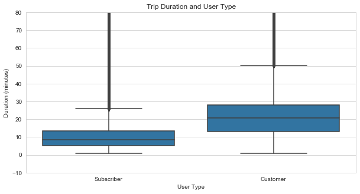

```python
# draw boxplot for Trip Duration and user_type
plt.figure(figsize = [10, 5])
sns.set_style("whitegrid")
base_color = sns.color_palette()[0]
sns.boxplot(data = df, x = 'user_type', y = 'trip_duration', color = base_color)
plt.ylim([-10, 80])
plt.title('Trip Duration and User Type')
plt.xlabel('User Type')
plt.ylabel('Duration (minutes)')
plt.show()
```

we can see that higher percentage of customer rides longer trips then subscriber.

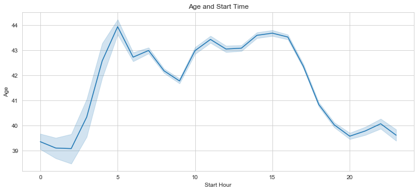

```python
# draw line plot for age and start time
plt.figure(figsize = [12, 5])
base_color = sns.color_palette()[0]
sns.lineplot(x = df['start_time_hour'] , y = df['User_age'], color=base_color);
plt.title('Age and Start Time');
plt.ylabel('Age');
plt.xlabel('Start Hour');
```

As we can see the old people tend to start their trip on early time but young people use the bike in late night

### Talk about some of the relationships you observed in this part of the investigation. How did the feature(s) of interest vary with other features in the dataset?

The relationship of the duration of the trip with age was not clear, but there is a relationship for people aged 51 as they spend a longer time on the trip than others. However, the relationship of gender to trip duration was in favor of females and others more than males, as females and others spend more time on the trip.Also,there is no clear relationship between the start and stop time and trip duration. finally، higher percentage of customer rides longer trips then subscriber.

### Did you observe any interesting relationships between the other features (not the main feature(s) of interest)?

I thought that subscriber which are having higher count will have higher trip duration but it is the opposite. Even for gender, value of male members is very high but it got lower trip duration.

## Multivariate Exploration

ow let's see how the three categorical measures of user type and gender into the relationship between trip duration and age.

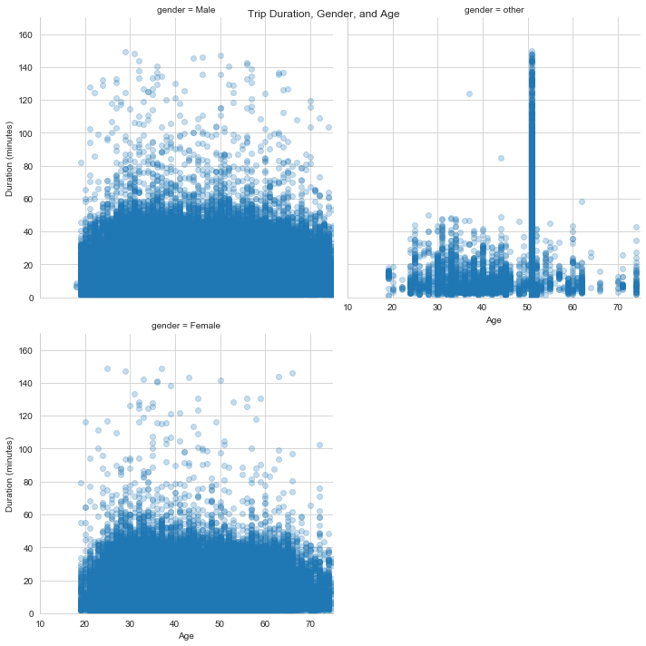

```python
# draw scatter for Trip Duration, Gender, and Age
gender = sns.FacetGrid(data = df, col = 'gender', col_wrap = 2, height = 5,
                 xlim = [10, 75], ylim = [0, 170])
gender.map(plt.scatter, 'User_age', 'trip_duration', alpha= 0.25)
gender.set_xlabels('Age')
gender.set_ylabels('Duration (minutes)')
gender.fig.suptitle('Trip Duration, Gender, and Age')
plt.show();
```

As we can see there are no clear relationship between trip duration and age , gender.

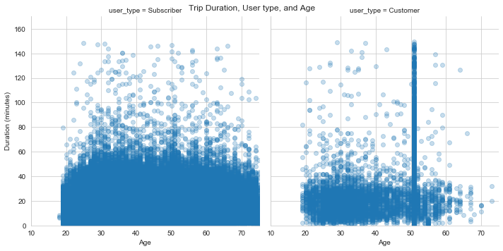

```python
# draw scatter for Trip Duration, User type, and Age
user_type = sns.FacetGrid(data = df, col = 'user_type', col_wrap = 2, height = 5,
                 xlim = [10, 75], ylim = [0, 170])
user_type.map(plt.scatter, 'User_age', 'trip_duration', alpha= 0.25)
user_type.set_xlabels('Age')
user_type.set_ylabels('Duration (minutes)')
user_type.fig.suptitle('Trip Duration, User type, and Age')
plt.show()
```

### Talk about some of the relationships you observed in this part of the investigation. Were there features that strengthened each other in terms of looking at your feature(s) of interest?

The graph shows that there is an accumulation of data for both males and females between 0 to 40 minutes while the other has the highest trip duration for aged 51.